# Personal activity monitoring device

L. Besnainou

21 février 2018

This assignment makes use of data from a personal activity monitoring device. This device collects data at 5 minute intervals through out the day. The data consists of two months of data from an anonymous individual collected during the months of October and November, 2012 and include the number of steps taken in 5 minute intervals each day.

```r
# Reading the data
activity <- read.csv("activity.csv",na.strings = "NA")
```

The variables included in this dataset are:

- steps: Number of steps taking in a 5-minute interval (missing values are coded as NA)
- date: The date on which the measurement was taken in YYYY-MM-DD format
- interval: Identifier for the 5-minute interval in which measurement was taken

## Histogram of the total number of steps taken each day

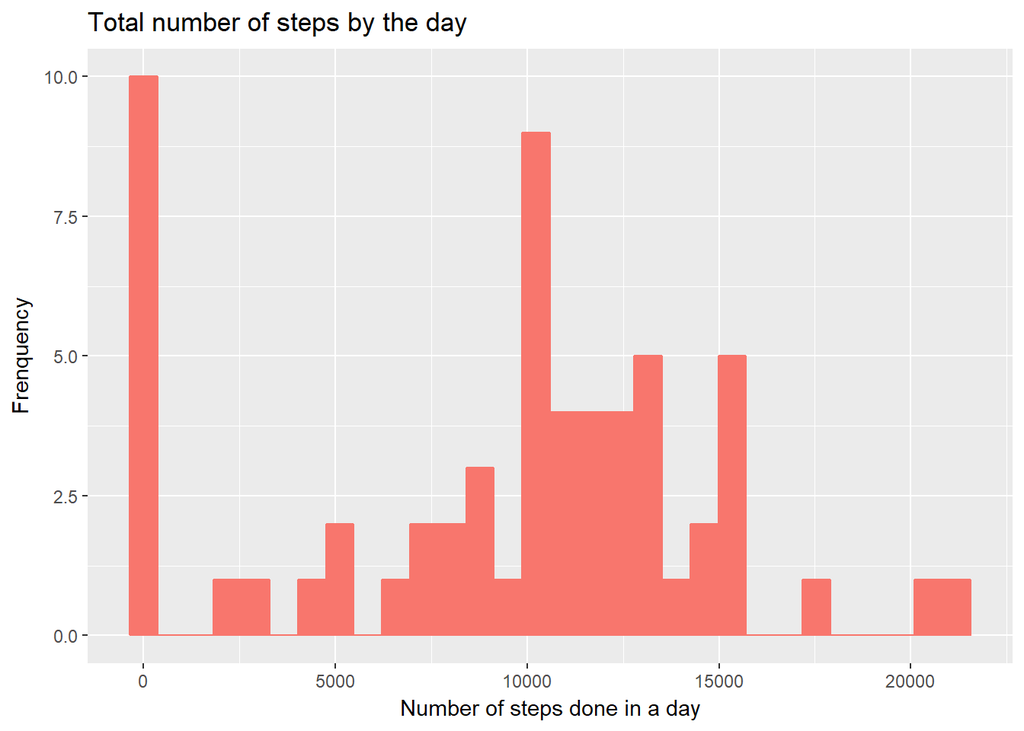

```r
#Transform the date column in a valide date format
activity$date <- ymd(activity$date)
#Make the histogram plot in ggplot2
ActivityDay <- activity %>% group_by(date) %>% summarize(numb=sum(steps,na.rm = TRUE))
qplot(numb, data=ActivityDay, main="Total number of steps by the day ",
      xlab="Number of steps done in a day", ylab="Frenquency", color="red", fill="red")+ theme(legend.position="none")
```

## Calculate the Mean and median number of steps by day

```r
summary(ActivityDay$numb)
```

```
##    Min. 1st Qu.  Median    Mean 3rd Qu.    Max.
##       0    6778   10395    9354   12811   21194
```

## Time series plot of the average number of steps taken

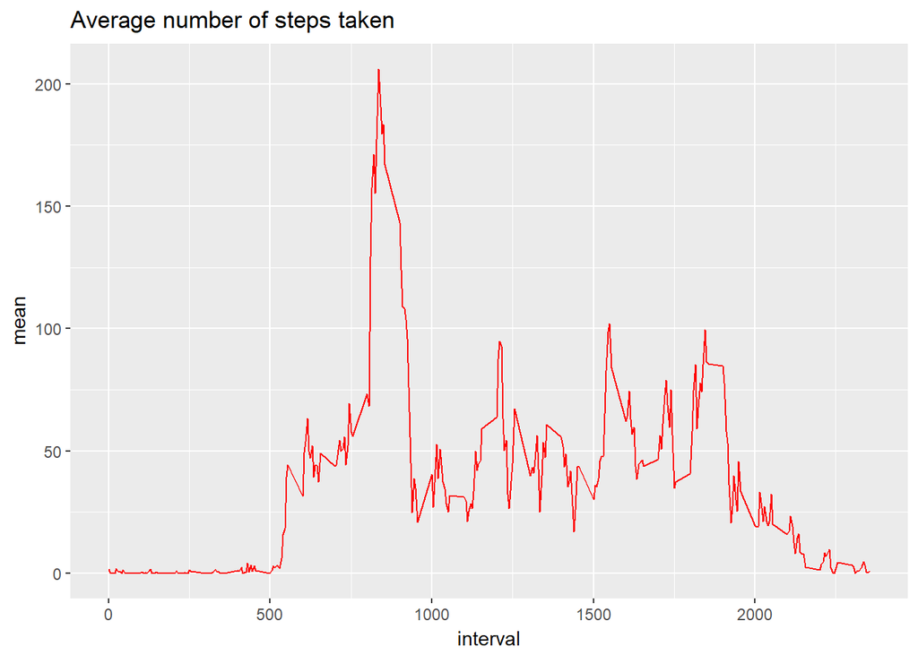

```r
activity %>% group_by(interval) %>% summarize(mean=mean(steps,na.rm = T)) %>% ggplot(aes(interval, mean)) + geom_line(colour = "red") + ggtitle ("Average number of steps taken")
```

## The 5-minute interval that, on average, contains the maximum number of steps

```r
IntervalAvg <- activity %>% group_by(interval) %>% summarise(mean=mean(steps,na.rm = T))
MaxInterval <- IntervalAvg[max(IntervalAvg$mean)==IntervalAvg$mean,]
```

The interval is 835 with an average number of steps 206.1698113

## Code to describe and show a strategy for imputing missing data

The missing values for the steps will be replace by the average value for the same interval (calculated in IntervalAvg R variable)

```r
#A left join will be made on dataframe Activity
activityNew <- left_join(activity,IntervalAvg,by = c("interval"))
activityNew$steps <-  ifelse(is.na(activityNew$steps), activityNew$mean, activityNew$steps)
```

## Histogram of the total number of steps taken each day after missing values are imputed

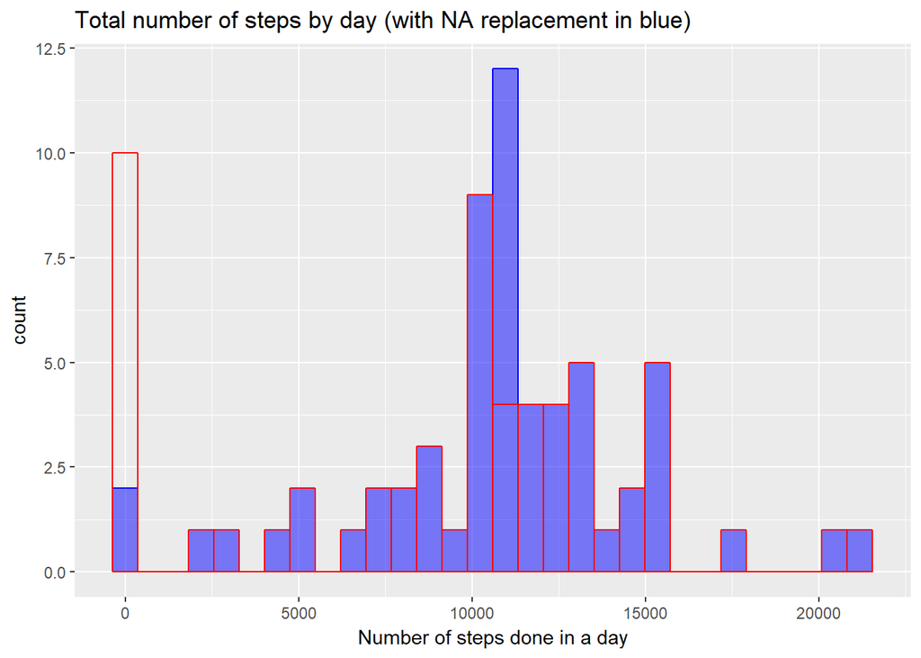

```r
#Display the graph for comparaison
ActivityDay <- activity %>% group_by(date) %>% summarize(numb=sum(steps,na.rm = TRUE))


ActivityDayNew <- activityNew %>% group_by(date) %>% summarize(numb=sum(steps,na.rm = TRUE))


 ggplot(data=ActivityDayNew, aes(numb))+
     geom_histogram(color="blue", fill = "blue", alpha = 0.5) +
        geom_histogram(data=ActivityDay,aes(numb),color="red", fill = NA,alpha = 0.4)+

      ggtitle ("Total number of steps by day (with NA replacement in blue)")+
     xlab("Number of steps done in a day")
```

## Panel plot comparing the average number of steps taken per 5-minute interval across weekdays and weekends

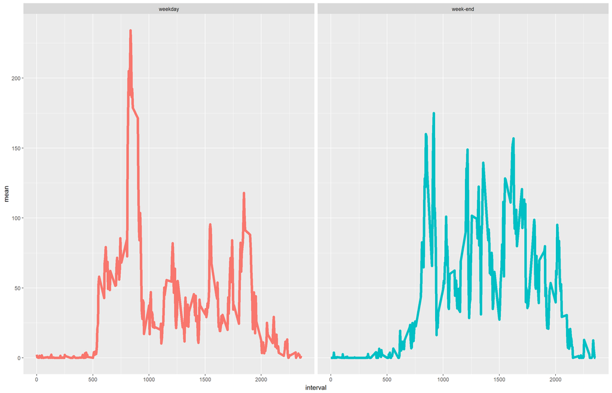

```r
#set weekday and week-end
activity$weekday <- weekdays(activity$date)
activity$wday <- wday(activity$date) %in% c(1,7)
activity$wday <-factor (activity$wday)
levels(activity$wday) <- c("weekday", "week-end")
p <- activity %>% group_by(interval,wday) %>% summarise(mean=mean(steps,na.rm = T)) %>%
ggplot(aes(interval,mean,color=wday)) +
  geom_line(show.legend=F,size=2)
p +  facet_wrap(~ wday)
```